# Bisphosphonates network meta-analysis: fever

2018-10-28

## Raw data

29 out of 51 studies reported an outcome of Fever. All grades combined.

[interactive chart not shown]

### Treatment groupings for analysis

Consider four alternative groupings from finer to coarser:

1. Biphosphonate drug, dose and delivery method. IV placebo, oral placebo and observation only distinguished.
2. Biphosphonate drug and delivery method.
3. Biphosphonate drug. IV and oral placebo grouped, but distinguished from observation only.
4. Drug class, considering all nitrogenous biphosphonates together. IV and oral placebo grouped, but distinguished from observation only.

### Notes

- Only study including Clodronate was NSABP B-34, whose control arm used oral placebo. 1 and 0 people with fever were reported in the active / control arms respectively, out of 1623, 1612. No other study used oral placebos. Exclude for now, but may be included later if we decide to combine all placebos or all controls.
- Two studies, ABCSG12 and HOBOE, included separate arms to compare a different kind of hormone therapy for the same biphosphonate (“main” treatment). To start with, define these as different treatments.

## Networks of comparisons

Number of studies for each comparison indicated on the connecting lines.

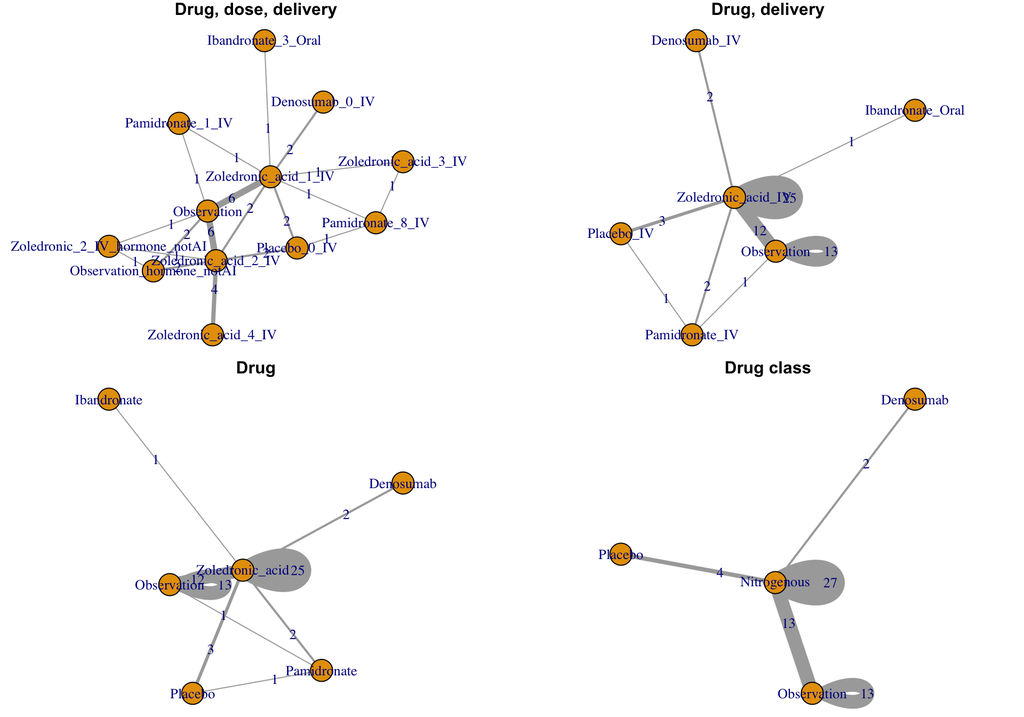

## Network meta analysis models

#### Model assumptions

- Relative effects for each comparison are “random effects”, normally distributed between studies with an unknown mean and variance
- Baseline rate of adverse events (that is, for “observation only” controls) is also a random effect. Log odds is normally distributed between studies with an unknown mean and variance.
- gemtc R package used, with code modified to deal with random baselines. Package default weakly informative priors.

The only relative effects which can’t be estimated from the data are those relating to Ibandronate. There is only one study for this drug (Body 2007) which reported data for fever. 26 out of 137 in the zoledronic acid arm reported fever, compared to 0 / 137 in the ibandronate arm. Unsure how to deal with this! Is it clinically plausible? We might be able to moderate this outlying result using some model which borrows information from other drugs which are similar to ibandronate? Or just merge all nitrogenous biphosphonates?

## Relative treatment effects

Estimates from each of the four network meta-analysis models, compared with direct data, for the comparisons where there is direct data.

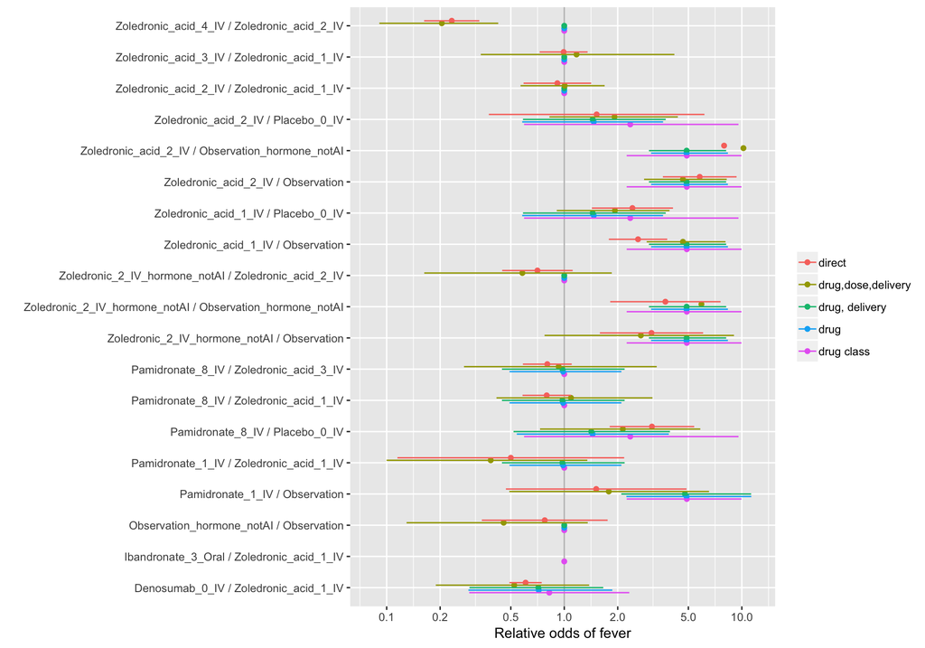

- Lower fever rates in Zoledronic acid dose definition 4 compared to other Zoledronic acid doses. Makes sense as this is “delayed” dosage?
- Not much difference between Zoledronic acid dose definitions 1, 2, 3
- Apparent difference between “placebo” and “observation only” controls when compared to Zoledronic acid dose 2. Sounds implausible. Consistent with unexplained between study heterogeneity
- Perhaps this causes the apparent overestimate (compared to direct data) of the effect of Zol 1 IV and Zol 2 IV (non-AI hormone) vs observation only.
- Pamidronate dose 8 - not much difference from Zoledronic acid dose def 1
- Pamidronate dose 1 appears to do better than Zol 1 (hence better than Pamidronate dose 8)
- Denosumab appears to do better than Zoledronate dose 1, but this effect is moderated under the model
- Note estimated relative odds is exactly 1 between e.g. two drugs in the same class under the “drug class” model, or two dosages or delivery methods of the same drug in the “drug” model.

The four alternative ways of grouping effects of similar treatments appear to give a similar fit to the data, according to standard methods of statistical model comparison (DIC)

## Absolute rates of fever

To produce the absolute event rate under each treatment:

- first the absolute rate under control (observation only) for a predicted new study is estimated
- then the relative odds for each treatment is applied to this

Posterior mean and 95% credible intervals

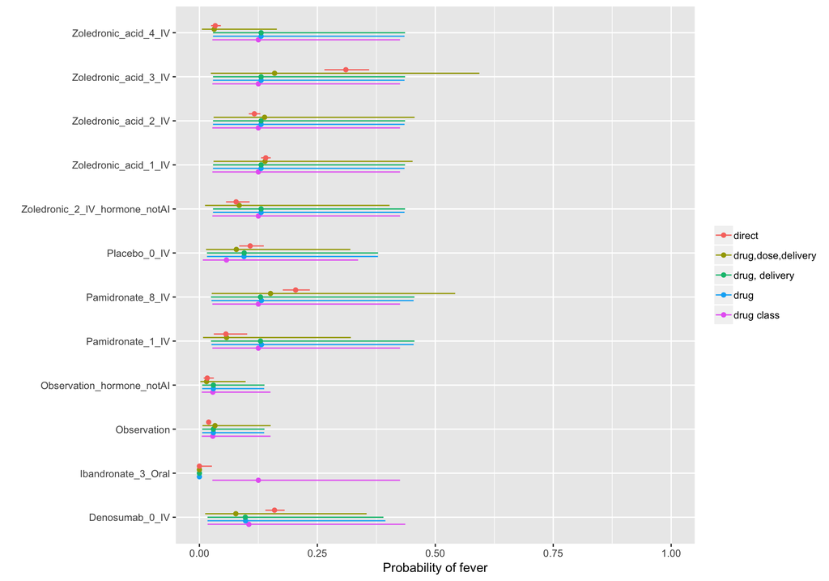

- Observation vs placebo strangeness
- More uncertainty in estimates from model, compared to raw data, reflecting between study heterogeneity in baseline rates

## TODO

More cross checking of all these model results against raw data

Study additional treatments

- check if variability in baseline event rate is explained by additional treatment. Add regression term.
- assess if *relative* effects vary between additional treatments.